# 3rd February

From this point onwards, jupyter is being run from an Anaconda Python 2.7 environment on Windows. All the libraries called are either standard, or can be installed from the anaconda prompt - part of the anaconda install - using

```
conda install [library]
```

## Signal Processing

Now that we have arranged all the sac data into a usable format, we need to start with the signal filtering, and the fourier transforms. Let's run through a single dataset first manually, and then we'll use the code we write to automate the rest.

At the moment we haven't processed any noise data - that will come later.

First, let's pull in our dataset into a dataframe.

```python
import numpy as np
import pandas as pd
import os
from __future__ import division
from numpy.fft import *
from scipy.signal import kaiser
import matplotlib.pyplot as plt
from tqdm import tqdm
from ipywidgets import FloatProgress
from IPython.display import display
%matplotlib notebook
```

```python
manual_dataframe = pd.read_csv("G:/Data/DATA/ASCII/AllData/headless_only/TimeseriesAndAmplitude/20110829.002440.YW.NAB1.HHE.txt", index_col="TimeSeries")
manual_dataframe
```

| TimeSeries | Amplitude |
| --- | --- |
| 0.0 | 276.566100 |
| 0.1 | 217.990400 |
| 0.2 | 121.538200 |
| 0.3 | 30.849630 |
| 0.4 | -12.855760 |
| 0.5 | -7.074997 |
| 0.6 | 6.970520 |
| 0.7 | -20.016690 |
| 0.8 | -94.747290 |
| 0.9 | -169.918400 |
| 1.0 | -197.413500 |
| 1.1 | -182.762200 |
| 1.2 | -164.845000 |
| 1.3 | -157.787300 |
| 1.4 | -133.985400 |
| 1.5 | -62.171360 |
| 1.6 | 44.155140 |
| 1.7 | 130.089700 |
| 1.8 | 159.230300 |
| 1.9 | 151.601400 |
| 2.0 | 141.455200 |
| 2.1 | 122.696700 |
| 2.2 | 71.410030 |
| 2.3 | -0.993849 |
| 2.4 | -50.881130 |
| 2.5 | -41.548110 |
| 2.6 | 34.034300 |
| 2.7 | 146.215500 |
| 2.8 | 246.805100 |
| 2.9 | 309.420700 |
| ... | ... |
| 2997.1 | 32.788320 |
| 2997.2 | 3.998890 |
| 2997.3 | -21.731600 |
| 2997.4 | -67.333700 |
| 2997.5 | -140.108600 |
| 2997.6 | -207.376400 |
| 2997.7 | -212.611500 |
| 2997.8 | -121.519700 |
| 2997.9 | 39.359960 |
| 2998.0 | 195.084300 |
| 2998.1 | 283.943200 |
| 2998.2 | 292.967100 |
| 2998.3 | 236.443000 |
| 2998.4 | 136.057600 |
| 2998.5 | 23.519960 |
| 2998.6 | -67.940080 |
| 2998.7 | -127.444900 |
| 2998.8 | -169.846700 |
| 2998.9 | -208.913200 |
| 2999.0 | -240.851600 |
| 2999.1 | -251.866900 |
| 2999.2 | -231.121200 |
| 2999.3 | -187.784100 |
| 2999.4 | -152.384800 |
| 2999.5 | -147.717700 |
| 2999.6 | -165.623000 |
| 2999.7 | -178.163500 |
| 2999.8 | -169.862900 |
| 2999.9 | -146.530400 |
| 3000.0 | -110.279000 |

30001 rows × 1 columns

The data looks fine, so let's take a look at the signal

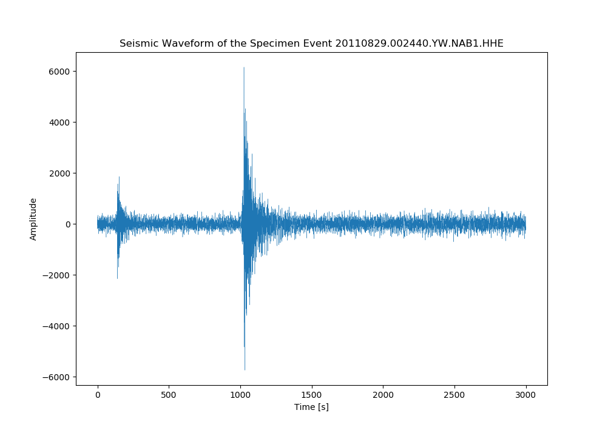

```python
fig, ax = plt.subplots()
ax.plot(manual_dataframe.index.values, manual_dataframe['Amplitude'], lw=0.3)
ax.set_xlabel("Time [s]")
ax.set_ylabel("Amplitude")
ax.set_title("Seismic Waveform of the Specimen Event 20110829.002440.YW.NAB1.HHE")
plt.show()
```

That looks like an definite event. It does seem to have two events within the recording, however there is a strong constant noise in the background that might be a continual tremor with an amplitude above an expected noise level, with the tremor increasing after both spike - potentially profiling two consecutive magmatic-driven mode 1 fractures and a resultant increase in magma flow.

[figure not shown]

Let's try to pull some of the signal components from the audio. I'm using the SciPy Fourier Transform functionality - you can find the official documentation [here](https://docs.scipy.org/doc/scipy/reference/tutorial/fftpack.html).

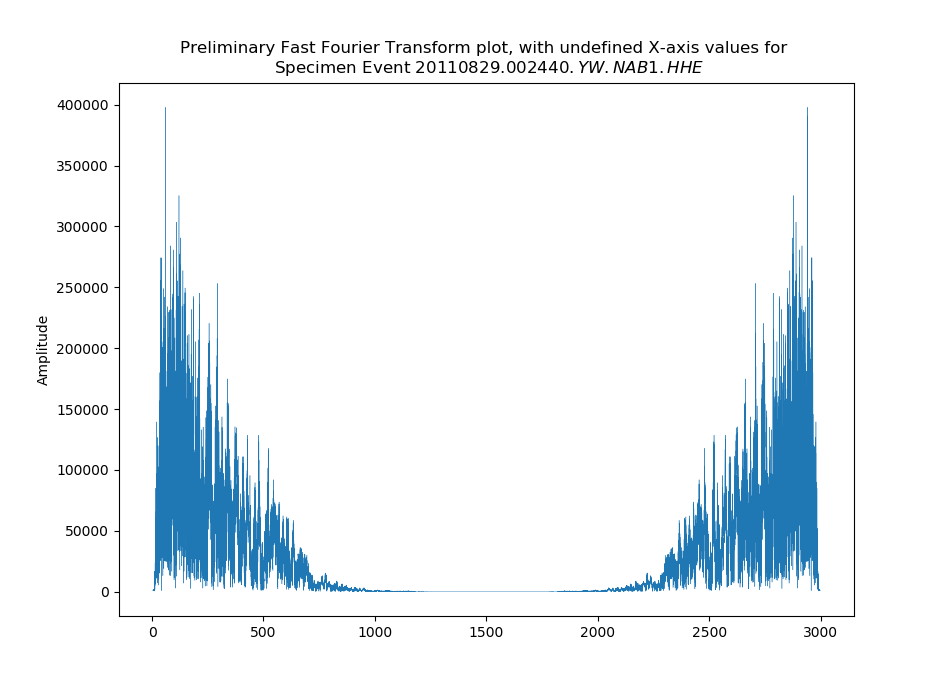

```python
fft_dataframe = manual_dataframe.copy()
fft_dataframe.Amplitude = np.fft.fft(manual_dataframe.Amplitude.values)
fft_dataframe.Amplitude = np.abs(fft_dataframe.Amplitude.values)

x_values = fft_dataframe.index.values
y_values = fft_dataframe.Amplitude

fig, ax = plt.subplots()
ax.plot(x_values, y_values, lw=0.3)
ax.set_ylabel("Amplitude")
ax.set_title("Preliminary Fast Fourier Transform plot, with undefined X-axis values for \n Specimen Event $20110829.002440.YW.NAB1.HHE$")
plt.show()
```

Now, that looks roughly like what we were expecting, but the x axis is distorted, and the mirroring is just clustering the plot. As a first stab it shows us that we are on the right track. Now let's clear up the code and do it properly.

Let's first find the actual frequencies for our x-axis, using the *np.fft.fftfreq()* function. We'll also start cleaning up the code in places.

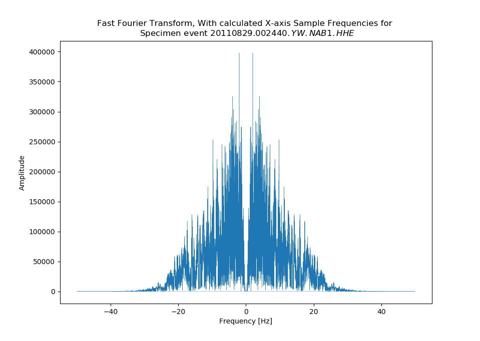

```python
y_values = fft_dataframe.Amplitude

no_of_datapoints = len(y_values)
time_interval = 0.01 #constant sample interval for all of the seismometers used

x_values = fftfreq(no_of_datapoints, d=time_interval)

fig, ax = plt.subplots()
ax.plot(x_values, y_values, lw=0.3)
ax.set_xlabel("Frequency [Hz]")
ax.set_ylabel("Amplitude")
ax.set_title("Fast Fourier Transform, With calculated X-axis Sample Frequencies for \n Specimen event $20110829.002440.YW.NAB1.HHE$")
plt.show()
```

Now that we know the frequencies, let's properly scale the x-axis and cut off the mirror to remove the negative mirror freqencies. The plot shows us that in this case there is very little signal beyond 40Hz. There is a second line across the base, which is simply a wraparound line from the 50Hz to the -50Hz point and doesn't exist. As we remove the mirror, this line should disappear.

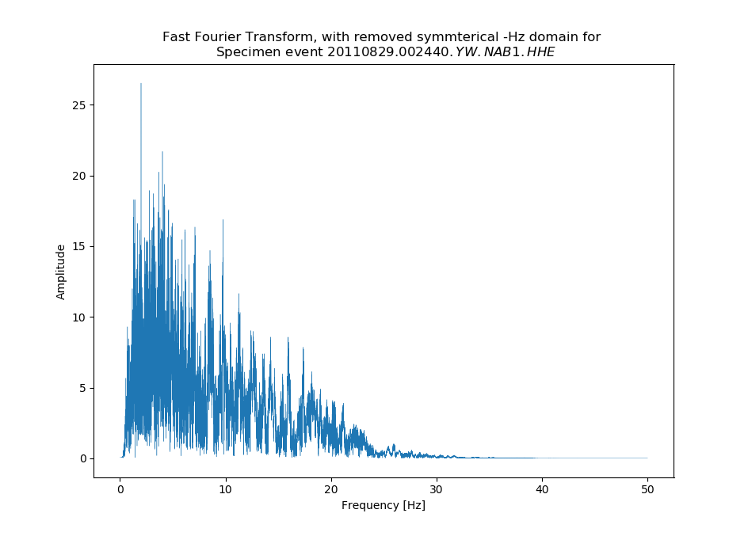

```python
fft_dataframe = manual_dataframe.copy()

y_values = np.fft.fft(manual_dataframe.Amplitude.values)

no_of_datapoints = len(y_values)
time_interval = 0.01 #constant sample interval for all of the seismometers used

yf_values = 2.0/no_of_datapoints * np.abs(y_values[:no_of_datapoints//2])

x_values = fftfreq(no_of_datapoints, d=time_interval)
xf_values = fftfreq(no_of_datapoints, d=time_interval)[:no_of_datapoints//2]

fig, ax = plt.subplots()
ax.plot(xf_values, yf_values, lw=0.3)
ax.set_xlabel("Frequency [Hz]")
ax.set_ylabel("Amplitude")
ax.set_title("Fast Fourier Transform, with removed symmterical -Hz domain for \n Specimen event $20110829.002440.YW.NAB1.HHE$")
plt.show()
```

Now that we can visually see the raw plot, let's see if we can clean the signal. We're going to use a kaiser windowing function to clean the data. there are several other options for filtering, including:

- Rectangular $[\sim 0\ \beta - max\ equivalance]$
- Hanning $[\sim 5\ \beta - max\ equivalance]$
- Hamming $[\sim 6\ \beta - max\ equivalance]$
- Blackman $[\sim 8.6\ \beta - max\ equivalance]$

However, these are largely static. A kaiser function allows us to tune it's $ \beta\ -max $ values to change the shape of window, and like the others mentions, is strictly a *apodization* as it works to remove the foot of the signal. Let's explore how the window changes as $\beta - max$ varies.

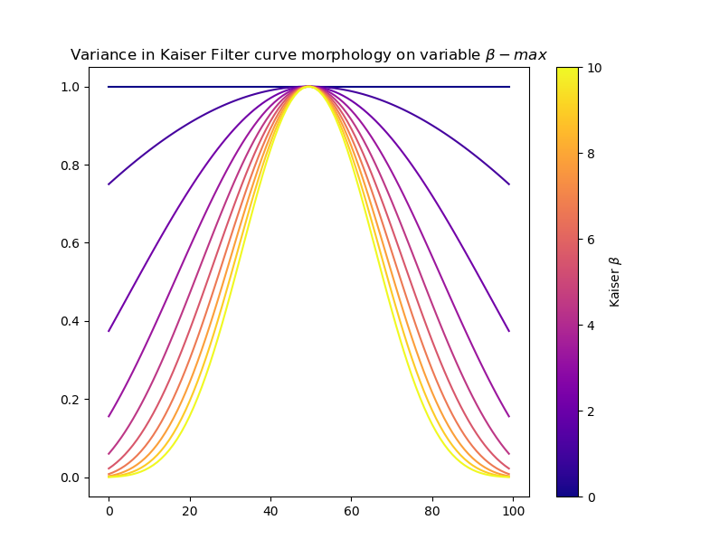

```python
f, ax1 = plt.subplots()

N=10
beta_max = 10
colormap = plt.cm.plasma

norm = plt.Normalize(vmin=0, vmax=beta_max)

lines = [ax1.plot(np.kaiser(100, beta), color=colormap(norm(beta))) for beta in np.linspace(0, beta_max, N)]

sm = plt.cm.ScalarMappable(cmap=colormap, norm=norm)

sm._A = []


ax1.set_title(r"Variance in Kaiser Filter curve morphology on variable $\beta -max$")


plt.colorbar(sm).set_label(r'Kaiser $\beta$');
```

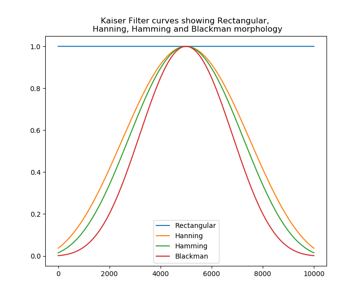

```python
fig, ax = plt.subplots()
lines = [ax.plot(np.kaiser(10000, beta)) for beta in [0, 5, 6, 8.6]]
ax.set_title("Kaiser Filter curves showing Rectangular, \n Hanning, Hamming and Blackman morphology")
ax.legend(["Rectangular", "Hanning", "Hamming", "Blackman"])
```

This lets us calibrate the windowing function if we need to, to help improve the end model's accuracy. For now, we'll use the documentation recommended $\beta\ max = 14$ value.